# Analysis of students performance in Maths course

Adity Bhargav(3814507), Anushka Sharma(3817004), Ramit Tyagi(3822900)

## Data Source and Description

The dataset titled ‘Student Alcohol Consumption’ has been sourced from :

Cortez, P. and Silva, A., 2008. Using Data Mining To Predict Secondary School Student Performance. [online] Kaggle. Available at: https://www.kaggle.com/uciml/student-alcohol-consumption [Accessed 15 September 2020].  
The data was obtained from a survey that was conducted for students who are enrolled in mathematics course. The survey was performed by asking students to fill a single A4 sheet of questionnaire containing 37 questions. It contains a lot of interesting social, gender and study information about the students. The data was collected in the academic year of 2005-06 from two public schools (Gabriel Pereira and Mousinho da Silveira) from the Alentejo region of Portugal. In Portugal, a 20-point grading scale is used to measure student’s performance, where 0 is the lowest grade and 20 is a perfect score.

In this study we have taken a closer look at the survey data for the students who are enrolled in mathematics course. The dataset used for this project is an open source file named (student-mat.csv), has 395 student observations across 33 variables. Furthermore, we will be utilizing the following variables: -

Data Description

| ï..NAME | DATA.TYPE | UNIT | DESCRIPTION |
| --- | --- | --- | --- |
| school | Binary | Unknown | Student’s school ‘GP’ - Gabriel Pereira or ‘MS’ - Mousinho da Silveira |
| sex | Binary | Unknown | Student’s sex ‘F’ - female or ‘M’ - male |
| age | Numeric | Years | Student’s age |
| address | Binary | Unknown | Student’s home address type |
| Mjob | Nominal | Unknown | Mother’s job |
| Fjob | Nominal | Unknown | Father’s job |
| reason | Nominal | Unknown | Reason to choose this school (close to ‘home’, school ‘reputation’, ‘course’ preference or ‘other’) |
| higher | Binary | Unknown | Wants to take higher education (yes or no) |
| internet | Binary | Unknown | Internet access at home (yes or no) |
| Dalc | Numeric | Unknown | Workday alcohol consumption: from 1 (very low) to 5 (very high) |
| Walc | Numeric | Unknown | Weekend alcohol consumption: from 1 (very low) to 5 (very high) |
| activities | Binary | Unknown | Extra-curricular activities (binary: yes or no) |
| G1 | Numeric | Unknown | First period grade: from 0 to 20, output target (Related with the course subject- Math) |
| G2 | Numeric | Unknown | Second period grade: from 0 to 20, output target (Related with the course subject- Math) |
| G3 | Numeric | Unknown | Final grade: from 0 to 20, output target (Related with the course subject- Math) |

The target feature for this data is **G3** that represents the final grade(output target) of students in maths course. The grade is dependent on several factors for instance internet accessibility, study-time, alcohol consumption, etc.

## Goals and Objective

The main objective of this survey data is to explore all the possible factors that affect the lifestyle and grades of students from two different schools, Gabriel Pereira and Mousinho da Silveir, who are enrolled in maths course. The aim is to contemplate the influence of several aspects on student’s life and their final grades. These factors will be explored using appropriate visualizing tools. The analysis will be conducted by examining various qualitative and quantitative factors that include gender, internet accessibility, parent’s education and occupation etc. Using exploratory data analysis with visual methods, some of the factors that are considered to have the most influence on students will be plotted. These features/aspects will be explored using visualization plots like bar graphs, pie charts, histograms and boxplots to understand their effect on student’s lifestyle and their academic performance. The results that will be generated from each plot may or may not vary from the original assumptions. The goal is to find out the major factors which actually have an impact on student’s final grades contemplating their drinking habits, their family background and all the other features/factors included in the survey data.  
The final outcome of this analysis can be used by teachers and parents all around the world to understand what all conditions affect a student’s grades and lifestyle. This understanding can further help the teachers and parents to develop more efficient ways of teaching and parenting.

## Data Cleaning & Preprocessing

```r
#Importing student-mat.csv

student_math<- read_csv("Group14_Data.csv")
#Type conversions
student_math$school<- factor(student_math$school, labels = c("Gabriel Pereira", "Mousinho da Silveira"))

student_math$sex<- factor(student_math$sex, labels = c("Female", "Male"))

student_math$address<- factor(student_math$address, labels = c("Rural", "Urban"))

student_math$famsize<- factor(student_math$famsize)

student_math$Pstatus<- factor(student_math$Pstatus, labels = c("Living apart", "Living together"))

student_math$Medu<- factor(student_math$Medu, labels = c("None", "Primary Education","5th to 9th grade", "Secondary Education", "Higher Education"))

student_math$Fedu<-factor(student_math$Fedu,labels = c("None", "Primary Education","5th to 9th grade", "Secondary Education", "Higher Education"))

student_math$Mjob<- factor(student_math$Mjob)

student_math$Fjob<- factor(student_math$Fjob)

student_math$reason<- factor(student_math$reason, labels = c("Course preference", "Distance from home", "Other reasons", "School reputation"))

student_math$internet<- factor(student_math$internet, labels = c("No", "Yes"))

student_math$Walc<- factor(student_math$Walc,labels = c("Very low", "Low", "Medium", "High", "Very High"))

student_math$Dalc<- factor(student_math$Dalc, labels = c("Very low", "Low", "Medium", "High", "Very High"))

student_math$higher<- factor(student_math$higher, labels = c("No", "Yes"))

student_math$studytime<- factor(student_math$studytime,labels = c("Less than 2 hours","2-5 hours","5-10 hours","Greater than 10 hours"))

student_math$activities<- factor(student_math$activities, labels = c("No","Yes"))

#Checking for missing values
colSums(is.na(student_math))
```

```
##     school        sex        age    address    famsize    Pstatus       Medu
##          0          0          0          0          0          0          0
##       Fedu       Mjob       Fjob     reason   guardian traveltime  studytime
##          0          0          0          0          0          0          0
##   failures  schoolsup     famsup       paid activities    nursery     higher
##          0          0          0          0          0          0          0
##   internet   romantic     famrel   freetime      goout       Dalc       Walc
##          0          0          0          0          0          0          0
##     health   absences         G1         G2         G3
##          0          0          0          0          0
```

```r
#Checking for special values
is.specialorNA <- function(x){
  if (is.numeric(x)) (is.infinite(x) | is.nan(x) | is.na(x))
}
sapply(student_math, function(x) sum( is.specialorNA(x) ))
```

```
##     school        sex        age    address    famsize    Pstatus       Medu
##          0          0          0          0          0          0          0
##       Fedu       Mjob       Fjob     reason   guardian traveltime  studytime
##          0          0          0          0          0          0          0
##   failures  schoolsup     famsup       paid activities    nursery     higher
##          0          0          0          0          0          0          0
##   internet   romantic     famrel   freetime      goout       Dalc       Walc
##          0          0          0          0          0          0          0
##     health   absences         G1         G2         G3
##          0          0          0          0          0
```

## Data Exploration & Visualisation

```r
#Statistical summary

#First period grade G1

summaryG1<- student_math %>% summarise(Min= min(G1, na.rm = TRUE),
                                     Q1= quantile(G1, probs = 0.25,na.rm = TRUE),
                                     Median= median(G1, na.rm = TRUE),
                                     Q3= quantile(G1,probs = 0.75, na.rm = TRUE),
                                     Max= max(G1, na.rm = TRUE),
                                     Mean= mean(G1, na.rm = TRUE),
                                     SD= sd(G1, na.rm = TRUE),
                                     N= n(),
                                     Missing= sum(is.na(G1)))
summaryG1
```

```
## # A tibble: 1 x 9
##     Min    Q1 Median    Q3   Max  Mean    SD     N Missing
##   <dbl> <dbl>  <dbl> <dbl> <dbl> <dbl> <dbl> <int>   <int>
## 1     3     8     11    13    19  10.9  3.32   395       0
```

```r
#Second period grade G1

summaryG2<- student_math %>% summarise(Min= min(G2, na.rm = TRUE),
                                     Q1= quantile(G2, probs = 0.25,na.rm = TRUE),
                                     Median= median(G2, na.rm = TRUE),
                                     Q3= quantile(G2,probs = 0.75, na.rm = TRUE),
                                     Max= max(G2, na.rm = TRUE),
                                     Mean= mean(G2, na.rm = TRUE),
                                     SD= sd(G2, na.rm = TRUE),
                                     N= n(),
                                     Missing= sum(is.na(G2)))
summaryG2
```

```
## # A tibble: 1 x 9
##     Min    Q1 Median    Q3   Max  Mean    SD     N Missing
##   <dbl> <dbl>  <dbl> <dbl> <dbl> <dbl> <dbl> <int>   <int>
## 1     0     9     11    13    19  10.7  3.76   395       0
```

```r
#Final grades G3

summaryG3<- student_math %>% summarise(Min= min(G3, na.rm = TRUE),
                                     Q1= quantile(G3, probs = 0.25,na.rm = TRUE),
                                     Median= median(G3, na.rm = TRUE),
                                     Q3= quantile(G3,probs = 0.75, na.rm = TRUE),
                                     Max= max(G3, na.rm = TRUE),
                                     Mean= mean(G3, na.rm = TRUE),
                                     SD= sd(G3, na.rm = TRUE),
                                     N= n(),
                                     Missing= sum(is.na(G3)))
summaryG3
```

```
## # A tibble: 1 x 9
##     Min    Q1 Median    Q3   Max  Mean    SD     N Missing
##   <dbl> <dbl>  <dbl> <dbl> <dbl> <dbl> <dbl> <int>   <int>
## 1     0     8     11    14    20  10.4  4.58   395       0
```

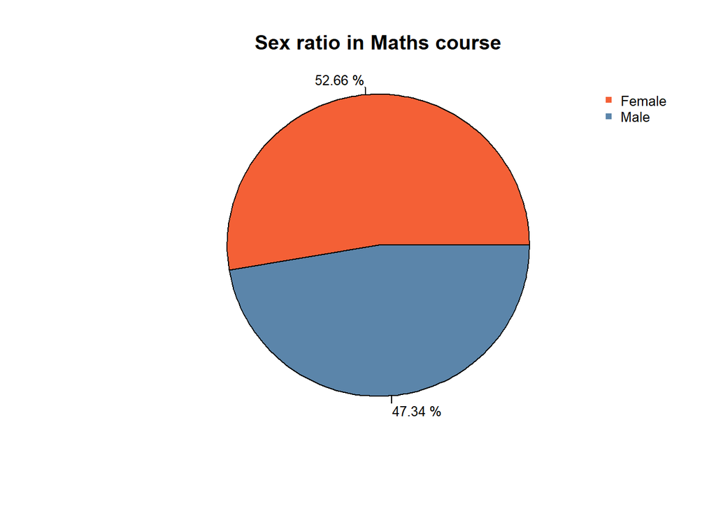

```r
#PLOT 1 - Sex Ratio in Maths course

freq1 <- as.data.frame(table(factor(student_math$sex)))
freq1Desc<- freq1[order(-freq1[-2]),]
sexfreq <- round(freq1Desc[,2]/sum(freq1Desc[,2])*100,2)
sexfreq <- paste(sexfreq,"%")

sex <- levels(freq1[, 1])


pie(freq1Desc[,2], labels=(sexfreq), col = c("#F46036", "#5B85AA"),
    main = "Sex ratio in Maths course",radius = 1.01, cex = .8)
legend("topright",inset = 0, bty = "n", legend=sex, col = c("#F46036", "#5B85AA"),
       pch = 15, cex = .8)
```

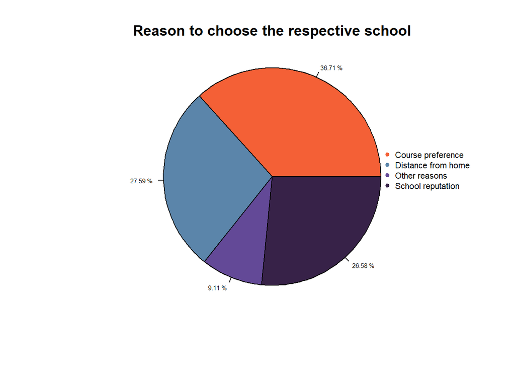

```r
#PLOT 2 - Reason to study in the respective school

freq2 <- as.data.frame(table(factor(student_math$reason)))
freq2Desc<- freq2[order(-freq2[-2]),]
reasonfreq <- round(freq2Desc[,2]/sum(freq2Desc[,2])*100,2)
reasonfreq <- paste(reasonfreq,"%")

reasons <- levels(freq2[, 1])


pie(freq2Desc[,2], labels=(reasonfreq), col =c("#F46036", "#5B85AA", "#634997", "#372248"),
    main = "Reason to choose the respective school",radius = 1.01, cex = .5)
legend(1,.3,inset = 0, bty = "n", legend=reasons, col =c("#F46036", "#5B85AA", "#634997", "#372248"),
       pch = 19, cex = 0.7)
```

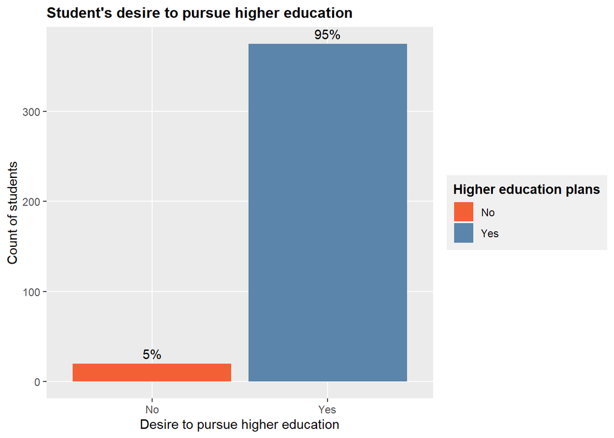

```r
#PLOT 3 - Desire to pursue higher education

p3<- ggplot(data = student_math, aes(x= higher, fill= higher))
p3 + geom_bar() +
  geom_text(aes(label = scales::percent(..prop..), group =2), stat="count", vjust = -0.5, position = position_dodge(0.9)) +
  scale_fill_manual(values = c("#F46036", "#5B85AA")) +
  guides(fill=guide_legend(title="Higher education plans")) +
  ggtitle(label = "Student's desire to pursue higher education") +
  labs(x= "Desire to pursue higher education", y= "Count of students") +
  theme(panel.grid.minor = element_blank(),
        panel.border = element_blank(),
        legend.background = element_rect(fill = "gray94"),
        legend.title = element_text(face = "bold"),
        plot.title = element_text(color = "black", size = 12, face = "bold"))
```

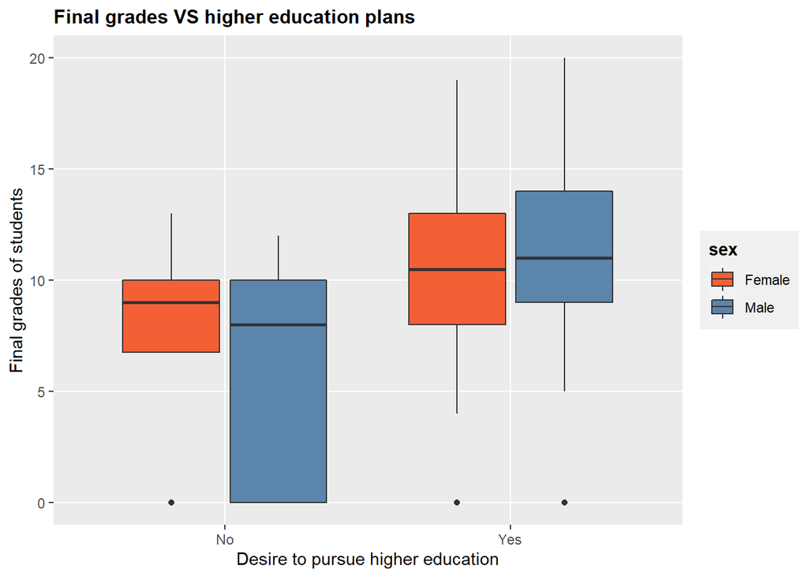

```r
#PLOT 4 - Final grades VS higher education plans for male and female students

p4<- ggplot(data = student_math, aes(x= higher, y= G3, fill= sex))
p4 + geom_boxplot() +
  scale_fill_manual(values = c("#F46036", "#5B85AA")) +
  ggtitle(label = "Final grades VS higher education plans") +
  labs(x= "Desire to pursue higher education", y= "Final grades of students")+
  theme(panel.grid.minor = element_blank(),
        panel.border = element_blank(),
        legend.background = element_rect(fill = "gray94"),
        legend.title = element_text(face = "bold"),
        plot.title = element_text(color = "black", size = 12, face = "bold"))
```

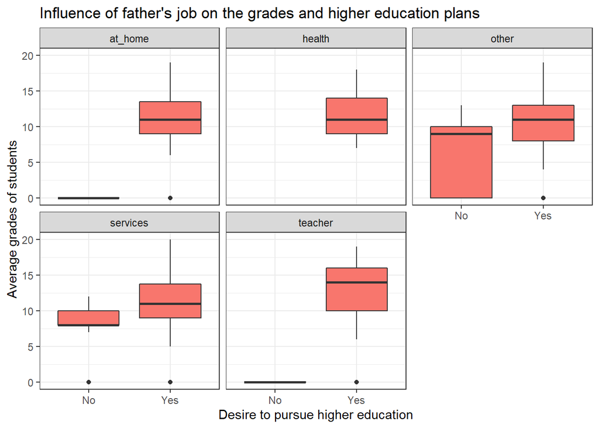

```r
#PLOT 5 - Influence of Father's job on the grades and higher education plans

p5<- ggplot(data = student_math, aes(x= higher, y= G3, fill= "#F46036"))
p5 + geom_boxplot() +
  facet_wrap(~Fjob) +
  ggtitle(label = "Influence of father's job on the grades and higher education plans") +
  labs(x= "Desire to pursue higher education",y= "Average grades of students") +
  theme(panel.grid.minor = element_blank(),
        panel.border = element_blank(),
        plot.title = element_text(color = "black", size = 12, face = "bold")) + theme_bw() +
  theme(legend.position = "none")
```

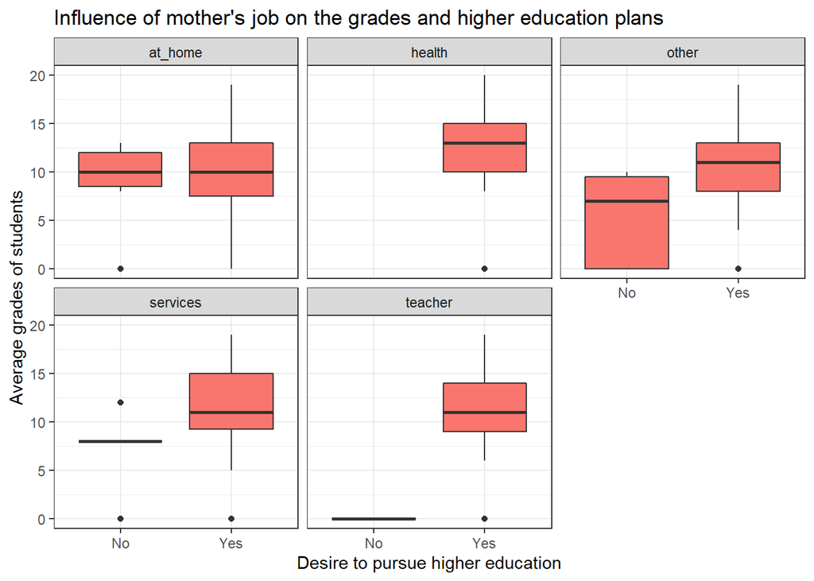

```r
#PLOT 6 - Influence of Mother's job on the grades and higher education plans

p6<- ggplot(data = student_math, aes(x= higher, y= G3, fill= "#F46036"))
p6 + geom_boxplot() +
  facet_wrap(~Mjob) +
  ggtitle(label = "Influence of mother's job on the grades and higher education plans") +
  labs(x= "Desire to pursue higher education",y= "Average grades of students") +
  theme(panel.grid.minor = element_blank(),
        panel.border = element_blank(),
        plot.title = element_text(color = "black", size = 12, face = "bold")) + theme_bw() +
  theme(legend.position = "none")
```

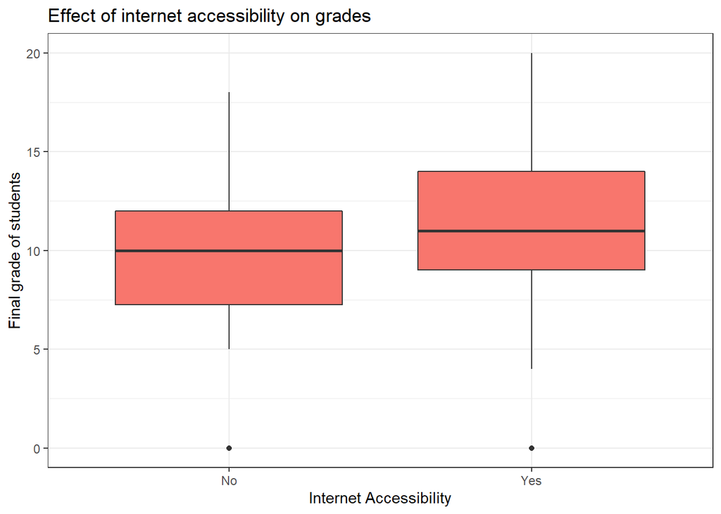

```r
#PLOT 7 - Effect of internet accessibility on grades

p7<- ggplot(student_math, aes(x=G3, y= internet,  fill= "#F46036"))
p7 + geom_boxplot() + coord_flip() +
  ggtitle("Effect of internet accessibility on grades") +
  labs(x="Final grade of students", y= "Internet Accessibility") +
  theme(axis.line = element_line(color = 'black')) +
  theme_bw() +
  theme(legend.position = "none")
```

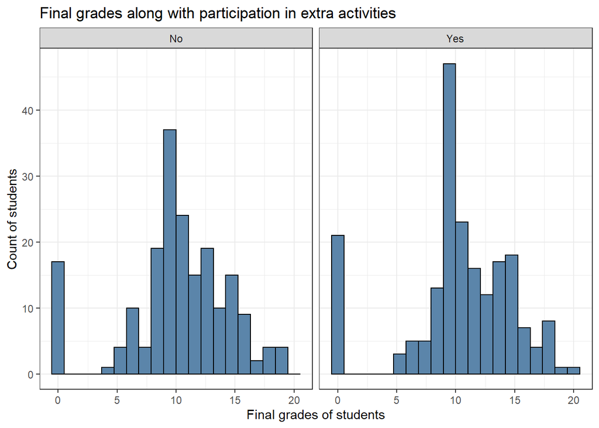

```r
#PLOT 8 - Final grades along with participation in extra activities

p8<- ggplot(student_math, aes(x=G3))
p8 + geom_histogram(bins = 20, color = "black", fill = "#5B85AA" ) +
  facet_wrap(~activities) + theme_bw() +
  ggtitle(label = "Final grades along with participation in extra activities") +
  labs(x= "Final grades of students",y= "Count of students")
```

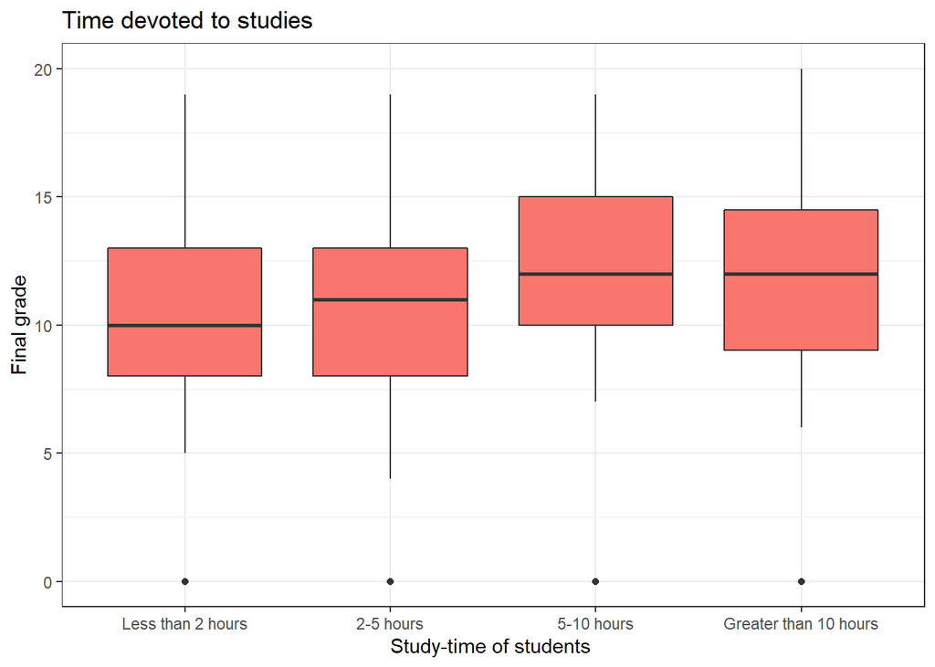

```r
#PLOT 9 - Influence of study time on the final grade of students

p9<- ggplot(data = student_math, aes(x= studytime, y= G3, fill= "#F46036"))
p9 + geom_boxplot() +
  ggtitle(label = "Time devoted to studies") +
  labs(x= "Study-time of students ",y= "Final grade") + theme_bw() +
  theme(legend.position="none")
```

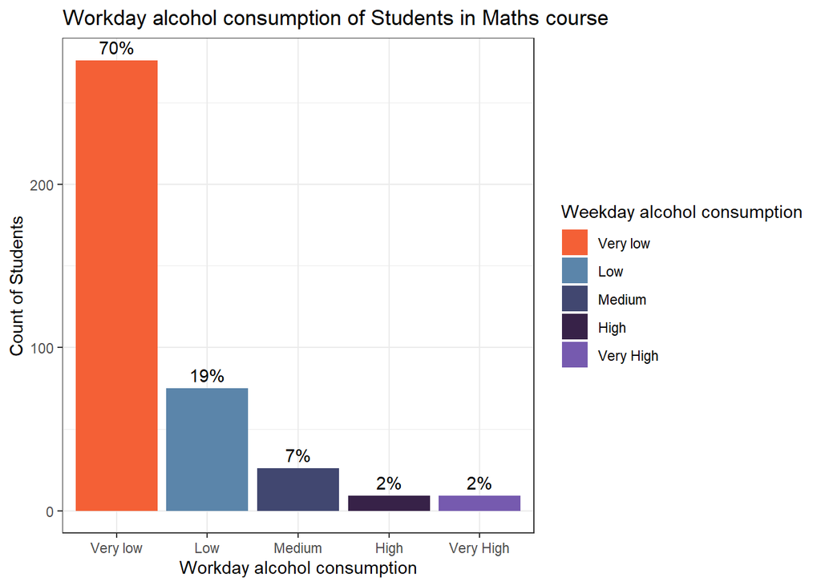

```r
#PLOT 10 - Workday alcohol consumption of Students in Maths course

p10 <- ggplot(student_math, aes(x=Dalc)) + geom_bar(aes(y = ..count.. , fill = Dalc),
                                                   stat="count", position = position_dodge(width = 0.9))
p10<- p10 + theme(axis.title.y = element_text(angle = 0, vjust=0.5)) +
  theme(axis.text = element_text(size = 8.5)) +
  labs(y = "Count of Students") + labs(x= "Workday alcohol consumption") + ggtitle("Workday alcohol consumption of Students in Maths course") +
  theme(plot.title = element_text(hjust = 0.5)) +
  scale_fill_manual(values=c("#F46036", "#5B85AA", "#414770", "#372248","#765AAF")) +
  geom_text(aes(label = scales::percent(..prop..), group =2), stat="count", vjust = -0.5, position = position_dodge(0.9)) + theme_bw() +
  guides(fill=guide_legend(title="Weekday alcohol consumption"))

p10
```

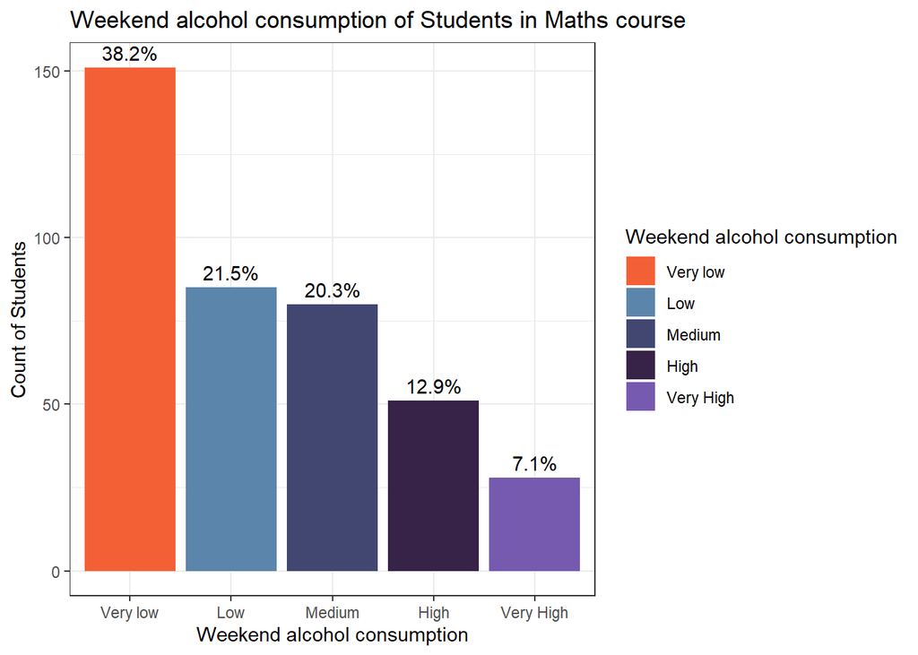

```r
#PLOT 11 - Weekend alcohol consumption of Students in Maths course

p11 <- ggplot(student_math, aes(x=Walc)) + geom_bar(aes(y = ..count.. , fill = Walc) ,
                                                   stat="count", position = position_dodge(width = 0.9))

p11 <- p11 + theme(axis.title.y = element_text(angle = 0, vjust=0.5)) +
  theme(axis.text = element_text(size = 8.5)) +
  labs(y = "Count of Students") + labs(x= "Weekend alcohol consumption") + ggtitle("Weekend alcohol consumption of Students in Maths course") +
  theme(plot.title = element_text(hjust = 0.5)) +
  geom_text(aes(label = scales::percent(..prop..), group =2), stat="count", vjust = -0.5, position = position_dodge(0.9)) +
  theme_bw() +
  scale_fill_manual(values=c("#F46036", "#5B85AA", "#414770", "#372248","#765AAF")) +
  guides(fill=guide_legend(title="Weekend alcohol consumption"))
p11
```

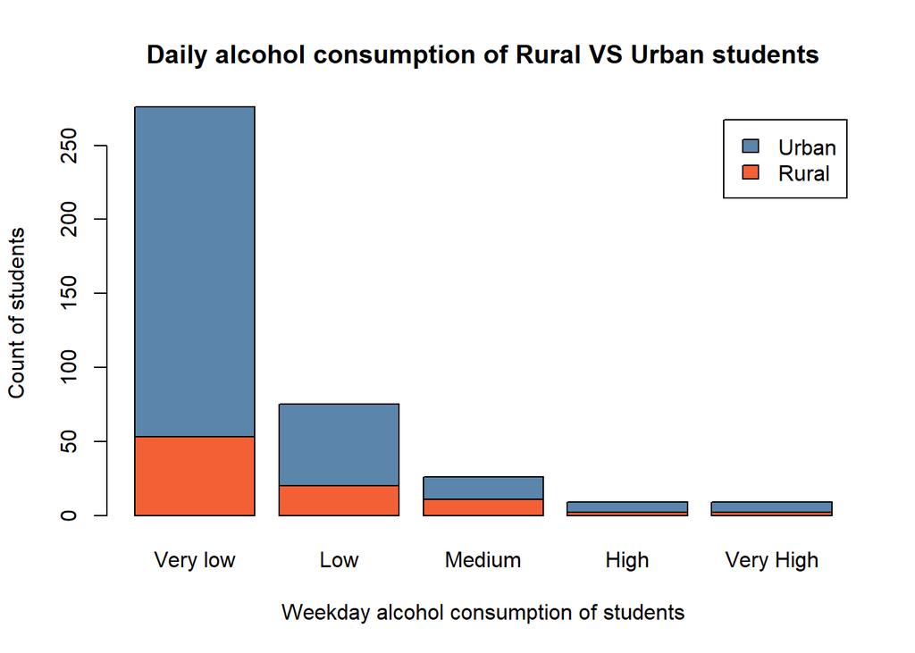

```r
#PLOT 12 - Workday alcohol consumption of Rural VS Urban students

table1 <- with(student_math, table(address, Dalc))


p12 <- barplot(table1, beside = FALSE, legend = TRUE,col=c("#F46036", "#5B85AA"), main = "Daily alcohol consumption of Rural VS Urban students",
              ylab = "Count of students", xlab = "Weekday alcohol consumption of students")
```

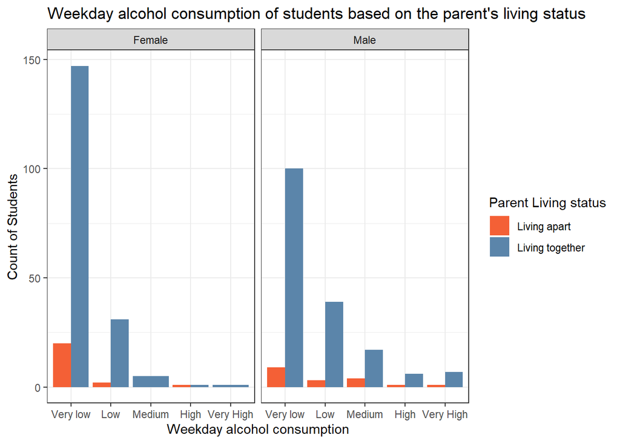

```r
#PLOT 13 - Weekday alcohol consumption of students based on the parent's living status

p13 <- ggplot(student_math, aes(x=Dalc), fill= c("#F46036", "#5B85AA")) + geom_bar(aes(y = ..count.. , fill = Pstatus) , stat="count", position = position_dodge(width = 0.9))
p13 <- p13 + facet_wrap(~sex) +
  theme(axis.title.y = element_text(angle = 0, vjust=0.5)) +
  theme(axis.text = element_text(size = 8.5))  +
  labs(y = "Count of Students") + labs(x= "Weekday alcohol consumption") + ggtitle("Weekday alcohol consumption of students based on the parent's living status") +
  theme(plot.title = element_text(hjust = 0.5)) + theme_bw() + guides(fill=guide_legend(title="Parent Living status")) +
  scale_fill_manual(values = c("#F46036", "#5B85AA"))

p13
```